# Introduction to text mining

Data Science: Introduction to Text Mining with R

## Today

## Course Materials

Everything for today (and more) can be found at

[www.ayoubbagheri.nl/r_tm](https://www.ayoubbagheri.nl/r_tm/)

## This lecture

- Basic commands in R & Rstudio
- Definitions of text mining
- Regular expressions

## Packages we use in these slides

```r
library(dplyr)      # data manipulation
library(magrittr)   # pipes
library(mice)       # for the boys data
library(ggplot2)    # visualization
library(DT)         # fancy JS/html tables
library(reshape2)   # melt stuff
```

## The data

```r
head(boys)
```

```
##      age  hgt   wgt   bmi   hc  gen  phb tv   reg
## 3  0.035 50.1 3.650 14.54 33.7 <NA> <NA> NA south
## 4  0.038 53.5 3.370 11.77 35.0 <NA> <NA> NA south
## 18 0.057 50.0 3.140 12.56 35.2 <NA> <NA> NA south
## 23 0.060 54.5 4.270 14.37 36.7 <NA> <NA> NA south
## 28 0.062 57.5 5.030 15.21 37.3 <NA> <NA> NA south
## 36 0.068 55.5 4.655 15.11 37.0 <NA> <NA> NA south
```

## Goal

At the end of this lecture we aim to understand what happens in

```r
ggplot(mutate(na.omit(select(boys, age, hgt, reg)), height_meters = hgt/100),
       aes(height_meters, age)) + geom_point(aes(group = reg))
```

## Pipes

## This is a pipe:

```r
boys %>%
  select(is.numeric) %>%
  cor(use = "pairwise.complete.obs") %>%
  round(3)
```

It effectively replaces `round(cor(select(boys, is.numeric), use = "pairwise.complete.obs"), digits = 3)`.

[figure not shown]

## Why are pipes useful?

Benefit: a single object in memory that is easy to interpret Your code becomes more readable:

- data operations are structured from left-to-right and not from in-to-out
- nested function calls are avoided
- local variables and copied objects are avoided
- easy to add steps in the sequence

## What do pipes do:

- `f(x)` becomes `x %>% f()`

```r
boys$age %>% mean()
```

```
## [1] 9.158866
```

- `f(x, y)` becomes `x %>% f(y)`

```r
boys %>% head(n = 1)
```

```
##     age  hgt  wgt   bmi   hc  gen  phb tv   reg
## 3 0.035 50.1 3.65 14.54 33.7 <NA> <NA> NA south
```

- `h(g(f(x)))` becomes `x %>% f %>% g %>% h`

```r
boys %>% select(is.numeric) %>% na.omit() %>% colMeans
```

```
##       age       hgt       wgt       bmi        hc        tv
##  14.07467 165.42411  54.01027  19.08348  55.28884  11.89732
```

## More pipe stuff

## The standard `%>%` pipe

[figure not shown]

## The `%$%` pipe

[figure not shown]

## The role of `.` in a pipe

In `a %>% b(arg1, arg2, arg3)`, `a` will become `arg1`. With `.` we can change this.

```r
boys %>%
  plot(bmi ~ age, data = .)
```

VS

```r
boys %$%
  plot(bmi ~ age)
```

The `.` can be used as a placeholder in the pipe.

## Data manipulation

## Performing a t-test in a pipe

```r
boys %>%
  mutate(ovwgt = bmi > 25) %$%
  t.test(age ~ ovwgt)
```

```
##
##  Welch Two Sample t-test
##
## data:  age by ovwgt
## t = -15.971, df = 32.993, p-value < 2.2e-16
## alternative hypothesis: true difference in means is not equal to 0
## 95 percent confidence interval:
##  -9.393179 -7.270438
## sample estimates:
## mean in group FALSE  mean in group TRUE
##            9.103392           17.435200
```

is the same as

```r
t.test(age ~ (bmi > 25), data = boys)
```

## Melting

```r
boys %>%
  select(reg, age) %>%
  melt(id.vars = "reg", variable.name = "variable", value.name = "value") %>%
  datatable(options = list(pageLength = 25, scrollY = "250px"))
```

|  | reg | variable | value |
| --- | --- | --- | --- |
| 1 | south | age | 0.035 |
| 2 | south | age | 0.038 |
| 3 | south | age | 0.057 |
| 4 | south | age | 0.06 |
| 5 | south | age | 0.062 |
| 6 | south | age | 0.068 |
| 7 | south | age | 0.068 |
| 8 | west | age | 0.071 |
| 9 | west | age | 0.071 |
| 10 | east | age | 0.073 |

[output cut: 738 more lines]

## Calculate statistics

```r
boys %>%
  select(reg, age) %>%
  melt(id.vars = "reg", variable.name = "variable", value.name = "value") %>%
  group_by(variable, reg) %>%
  summarise_all(list(mean = mean, sd = sd), na.rm = TRUE) %>%
  datatable(options = list(pageLength = 25, scrollY = "200px"))
```

|  | variable | reg | mean | sd |
| --- | --- | --- | --- | --- |
| 1 | age | north | 11.8984197530864 | 6.77226802826091 |
| 2 | age | east | 9.24163354037267 | 6.47100104957633 |
| 3 | age | west | 8.99762761506276 | 7.06419498106435 |
| 4 | age | south | 8.59103141361257 | 6.88614896494616 |
| 5 | age | city | 8.27179452054795 | 6.79172286880407 |
| 6 | age |  | 1.332 | 2.09269969178571 |

## Multiple columns

```r
boys %>%
  select(reg, where(is.numeric)) %>%
  melt(id.vars = "reg", variable.name = "variable", value.name = "value") %>%
  group_by(variable, reg) %>%
  summarise_all(list(mean = mean, sd = sd), na.rm = TRUE) %>%
  datatable(options = list(pageLength = 25, scrollY = "200px"))
```

|  | variable | reg | mean | sd |
| --- | --- | --- | --- | --- |
| 1 | age | north | 11.8984197530864 | 6.77226802826091 |
| 2 | age | east | 9.24163354037267 | 6.47100104957633 |
| 3 | age | west | 8.99762761506276 | 7.06419498106435 |
| 4 | age | south | 8.59103141361257 | 6.88614896494616 |
| 5 | age | city | 8.27179452054795 | 6.79172286880407 |
| 6 | age |  | 1.332 | 2.09269969178571 |
| 7 | hgt | north | 151.63164556962 | 43.8495199058705 |
| 8 | hgt | east | 133.964779874214 | 43.2003415632957 |
| 9 | hgt | west | 130.278260869565 | 47.9968335611498 |
| 10 | hgt | south | 128.002150537634 | 46.3262869245427 |

[output cut: 26 more lines]

## Mutate: add

```r
boys %>%
  mutate(bmi_calc = wgt / (hgt/100)^2) %>%
  select(bmi, bmi_calc) %>%
  head()
```

```
##      bmi bmi_calc
## 3  14.54 14.54177
## 4  11.77 11.77395
## 18 12.56 12.56000
## 23 14.37 14.37589
## 28 15.21 15.21361
## 36 15.11 15.11241
```

## Mutate: remove

```r
boys %>%
  mutate(reg = NULL,
         gen = NULL,
         phb = NULL) %>%
  head()
```

```
##      age  hgt   wgt   bmi   hc tv
## 3  0.035 50.1 3.650 14.54 33.7 NA
## 4  0.038 53.5 3.370 11.77 35.0 NA
## 18 0.057 50.0 3.140 12.56 35.2 NA
## 23 0.060 54.5 4.270 14.37 36.7 NA
## 28 0.062 57.5 5.030 15.21 37.3 NA
## 36 0.068 55.5 4.655 15.11 37.0 NA
```

## Mutate: change

```r
boys %>%
  mutate(hgt = hgt/100) %>%
  tail()
```

```
##         age   hgt  wgt   bmi   hc  gen  phb tv   reg
## 7410 20.372 1.887 59.8 16.79 55.2 <NA> <NA> NA  west
## 7418 20.429 1.811 67.2 20.48 56.6 <NA> <NA> NA north
## 7444 20.761 1.891 88.0 24.60   NA <NA> <NA> NA  west
## 7447 20.780 1.935 75.4 20.13   NA <NA> <NA> NA  west
## 7451 20.813 1.890 78.0 21.83 59.9 <NA> <NA> NA north
## 7475 21.177 1.818 76.5 23.14   NA <NA> <NA> NA  east
```

## Mutate: transform column

```r
boys %$% table(reg)
```

```
## reg
## north  east  west south  city
##    81   161   239   191    73
```

```r
boys %>%
  select(hgt, reg) %>%
  mutate(across(!hgt, as.numeric)) %$%
  table(reg)
```

```
## reg
##   1   2   3   4   5
##  81 161 239 191  73
```

## rowwise

```r
boys %>%
  na.omit %>%
  rowwise() %>%
  mutate(tanner = mean(c(gen, phb))) %>%
  select(gen, phb, tanner) %>%
  head()
```

```
## # A tibble: 6 x 3
## # Rowwise:
##   gen   phb   tanner
##   <ord> <ord>  <dbl>
## 1 G1    P1       1
## 2 G2    P1       1.5
## 3 G1    P1       1
## 4 G1    P1       1
## 5 G2    P1       1.5
## 6 G1    P1       1
```

## Data visualization with `ggplot2`

## The `anscombe` data

```r
anscombe
```

```
##    x1 x2 x3 x4    y1   y2    y3    y4
## 1  10 10 10  8  8.04 9.14  7.46  6.58
## 2   8  8  8  8  6.95 8.14  6.77  5.76
## 3  13 13 13  8  7.58 8.74 12.74  7.71
## 4   9  9  9  8  8.81 8.77  7.11  8.84
## 5  11 11 11  8  8.33 9.26  7.81  8.47
## 6  14 14 14  8  9.96 8.10  8.84  7.04
## 7   6  6  6  8  7.24 6.13  6.08  5.25
## 8   4  4  4 19  4.26 3.10  5.39 12.50
## 9  12 12 12  8 10.84 9.13  8.15  5.56
## 10  7  7  7  8  4.82 7.26  6.42  7.91
## 11  5  5  5  8  5.68 4.74  5.73  6.89
```

## The same statistical properties

```r
anscombe %>% colMeans()
```

```
##       x1       x2       x3       x4       y1       y2       y3       y4
## 9.000000 9.000000 9.000000 9.000000 7.500909 7.500909 7.500000 7.500909
```

```r
anscombe %>% cor() %>% round(digits = 3) %>% .[1:4, 5:8]
```

```
##        y1     y2     y3     y4
## x1  0.816  0.816  0.816 -0.314
## x2  0.816  0.816  0.816 -0.314
## x3  0.816  0.816  0.816 -0.314
## x4 -0.529 -0.718 -0.345  0.817
```

```r
anscombe %>% var() %>% round(digits = 3) %>% .[1:4, 5:8]
```

```
##        y1     y2     y3     y4
## x1  5.501  5.500  5.497 -2.115
## x2  5.501  5.500  5.497 -2.115
## x3  5.501  5.500  5.497 -2.115
## x4 -3.565 -4.841 -2.321  5.499
```

## Fitting a line

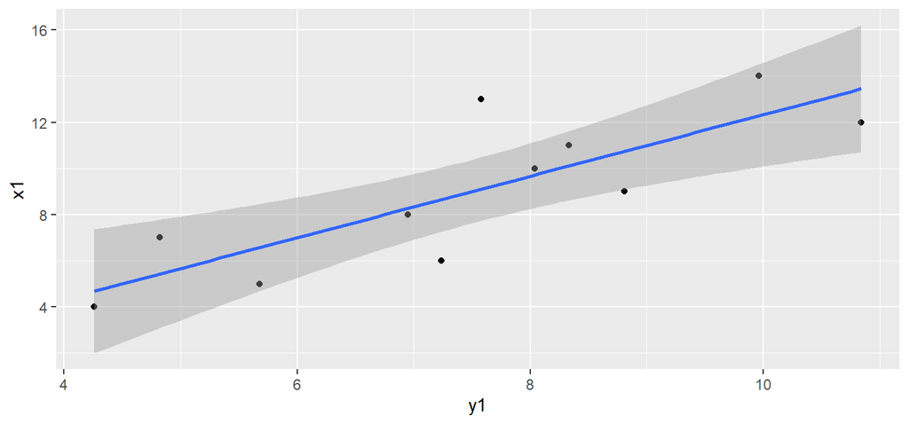

```r
anscombe %>%
  ggplot(aes(y1, x1)) +
  geom_point() +
  geom_smooth(method = "lm")
```

## Why visualise?

- We can process a lot of information quickly with our eyes
- Plots give us information about
  - Distribution / shape
  - Irregularities
  - Assumptions
  - Intuitions
- Summary statistics, correlations, parameters, model tests, *p*-values do not tell the whole story

### ALWAYS plot your data!

## Why visualise?

[figure not shown]

Source: Anscombe, F. J. (1973). “Graphs in Statistical Analysis”. American Statistician. 27 (1): 17–21.

## Why visualise?

[figure not shown]

## What is `ggplot2`?

Layered plotting based on the book **The Grammer of Graphics** by Leland Wilkinsons.

With `ggplot2` you

1. provide the *data*
2. define how to map variables to *aesthetics*
3. state which *geometric object* to display
4. (optional) edit the overall *theme* of the plot

`ggplot2` then takes care of the details

## An example: scatterplot

1: Provide the data

```r
mice::boys %>%
  ggplot()
```

2: map variable to aesthetics

```r
mice::boys %>%
  ggplot(aes(x = age, y = bmi))
```

3: state which geometric object to display

```r
mice::boys %>%
  ggplot(aes(x = age, y = bmi)) +
  geom_point()
```

## An example: scatterplot

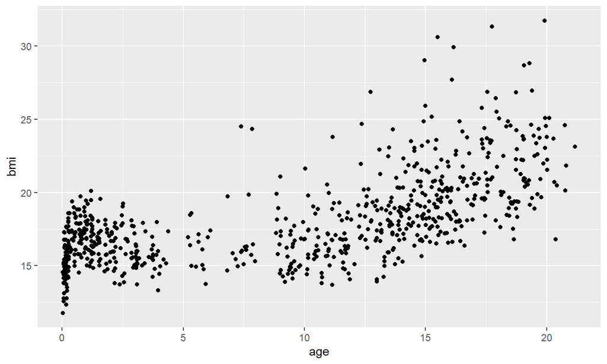

## Why this syntax?

Create the plot

```r
gg <-
  mice::boys %>%
  ggplot(aes(x = age, y = bmi)) +
  geom_point(col = "dark green")
```

Add another layer (smooth fit line)

```r
gg <- gg +
  geom_smooth(col = "dark blue")
```

Give it some labels and a nice look

```r
gg <- gg +
  labs(x = "Age", y = "BMI", title = "BMI trend for boys") +
  theme_minimal()
```

## Why this syntax?

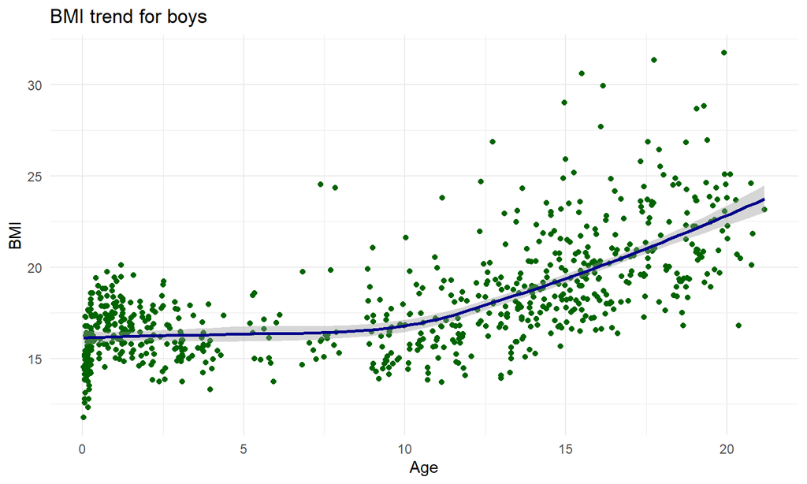

```r
plot(gg)
```

## Why this syntax?

[figure not shown]

## Revisit the start

```r
ggplot(mutate(na.omit(select(boys, age, hgt, reg)), height_meters = hgt/100),
       aes(height_meters, age)) + geom_point(aes(group = reg))
```

Is the same as

```r
boys %>%
  select(age, hgt, reg) %>%
  na.omit() %>%
  mutate(height_meters = hgt/100) %>%
  ggplot(aes(x = height_meters, y = age)) +
  geom_point(aes(group = reg))
```